# Ejercicio 2 - R

```r
str(df_sample_minium_nights)
```

```
## 'data.frame':    9005 obs. of  9 variables:
##  $ host_is_superhost     : chr  "SI" "SI" "SI" "SI" ...
##  $ host_identity_verified: chr  "NO VERIFICA" "VERIFICA" "NO VERIFICA" "VERIFICA" ...
##  $ bathrooms             : int  3 3 3 3 5 3 3 3 3 3 ...
##  $ bedrooms              : int  1 1 1 1 1 1 1 1 1 1 ...
##  $ daily_price           : int  94 125 100 120 700 250 100 280 320 240 ...
##  $ security_deposit      : int  1 31 1 48 1 73 13 1 1 1 ...
##  $ minimum_nights        : int  2 2 2 2 1 1 1 1 1 1 ...
##  $ number_of_reviews     : int  84 3 70 57 72 126 377 22 31 1 ...
##  $ review_scores_rating  : int  94 100 97 97 96 98 94 95 95 40 ...
```

```r
# Tras aplicar el filtro, la longitud del dataframe se ha reducido de 9322 filas, como se puede comprobar en el ejercicio anterior, a 9005 filas.
```

7. ¿Cuál es el precio medio por día de una habitación en función de si el anfitrión tiene verificado o no su perfil?

```r
# Concatenamos las siguientes funciones: primero, seleccionamos las columnas a tener en cuenta, después agrupamos los datos de la variable "host_identity_verified" y, a continuación, mostramos la estadística aplicada sobre la variable "daily_price", en este caso la media.

df_sample %>% select(host_identity_verified, daily_price) %>% group_by(host_identity_verified) %>% summarise(mean_daily_price = mean(daily_price))
```

| host_identity_verified | mean_daily_price |
| --- | --- |
| NO VERIFICA | 103.7647 |
| VERIFICA | 103.7127 |

```r
# Se puede comprobar que ambos precios medios no varían de manera significativa en función de si el anfitrión tiene verificado o no su perfil.
```

8. Quién tiene más número de reseñas, ¿un *super host* o no *super host*?

```r
# Realizamos este ejercicio de manera similar al anterior, incluyendo como estadística a obtener el valor máximo del número de reseñas:

df_sample %>% select(host_is_superhost, number_of_reviews) %>% group_by(host_is_superhost) %>% summarise(max(number_of_reviews))
```

| host_is_superhost | max(number_of_reviews) |
| --- | --- |
| NO | 791 |
| SI | 645 |

```r
# Un alojamiento categorizado como "no super host" ha obtenido un número de reseñas superior al número máximo de reseñas de un "super host".
```

9. Sobre la estadística anterior ¿quién tiene la puntuación media más alta?

```r
# A pesar de la falta de claridad de la pregunta, entendemos que se desea obtener la puntuación media de las calificaciones obtenidas en las reseñas ("review_scores_rating") teniendo en cuenta, como en la cuestión anterior, las categorías de la variable "host_is_superhost". Esto se calcularía de manera semejante a los dos ejercicios precedentes.

df_sample %>% select(host_is_superhost, review_scores_rating) %>% group_by(host_is_superhost) %>% summarise(mean_scores = mean(review_scores_rating))
```

| host_is_superhost | mean_scores |
| --- | --- |
| NO | 96.92425 |
| SI | 91.61382 |

```r
# La puntuación media de los alojamientos categorizados como "no super host" es superior (96.92) a la puntuación media de los alojamientos "super host" (91.61).
```

10. Crea un vector categórico llamado “CATEGORÍA”, en función de que, si para la puntuación de las reseñas tiene de 0 a 49, sea “NO ACONSEJABLE”; de 50 a 75 sea “ESTÁNDAR”; y de 76 a 100 sea “TOP”.

```r
# Creamos el vector para ser incluido como una nueva columna, al que asignamos la sentencia condicional indicada en el enunciado. Lo hacemos a través de la función "ifelse", que es la versión vectorizada del condicional "if else".

df_sample$CATEGORIA <- factor(ifelse(df_sample$review_scores_rating <= 49, "NO ACONSEJABLE", ifelse(df_sample$review_scores_rating <= 75, "ESTANDAR", "TOP")))

head(df_sample) # Comprobamos que los cambios se han aplicado.
```

| host_is_superhost | host_identity_verified | bathrooms | bedrooms | daily_price | security_deposit | minimum_nights | number_of_reviews | review_scores_rating | CATEGORIA |
| --- | --- | --- | --- | --- | --- | --- | --- | --- | --- |
| SI | NO VERIFICA | 3 | 1 | 94 | 1 | 2 | 84 | 94 | TOP |
| SI | VERIFICA | 3 | 1 | 125 | 31 | 2 | 3 | 100 | TOP |
| SI | NO VERIFICA | 3 | 1 | 100 | 1 | 2 | 70 | 97 | TOP |
| SI | VERIFICA | 3 | 1 | 120 | 48 | 2 | 57 | 97 | TOP |
| NO | VERIFICA | 3 | 0 | 70 | 13 | 30 | 44 | 90 | TOP |
| SI | NO VERIFICA | 3 | 1 | 200 | 48 | 15 | 79 | 98 | TOP |

11. Mostrar las frecuencias de la variable CATEGORÍA.

```r
# "table" muestra la frecuencia de los valores únicos de una variable.

table(df_sample$CATEGORIA)
```

| ESTANDAR | NO ACONSEJABLE | TOP |
| --- | --- | --- |
| 263 | 42 | 9017 |

```r
# La mayor parte de los alojamientos obtienen la categoría de "Top", seguido por un valor bastante más inferior por la categoría "Estandar" y una reducida parte por la categoría "No aconsejable", de acuerdo a la puntuación de las reseñas.
```

12. Obtener el histograma del precio por día.

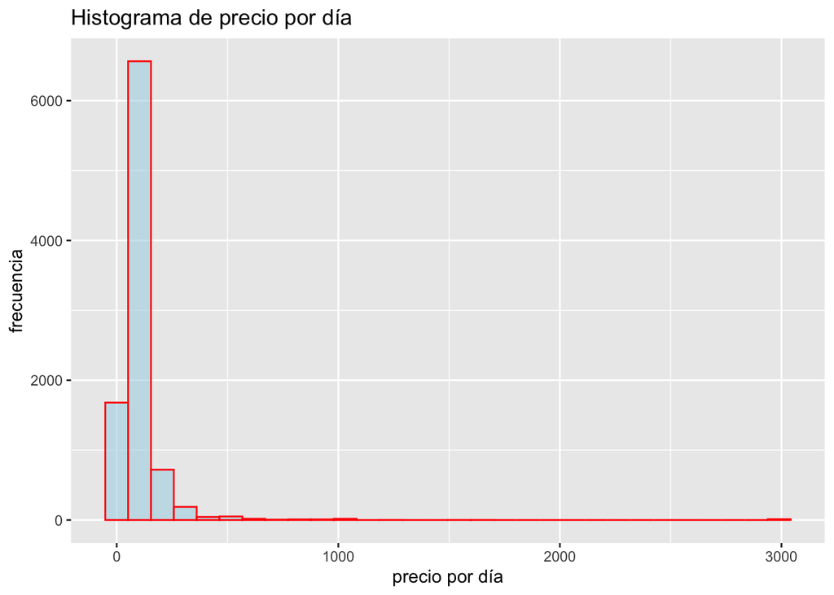

```r
ggplot(df_sample) +
  geom_histogram(mapping = aes(daily_price), color = "red", fill = "lightblue", alpha = 0.6) +
  ggtitle("Histograma de precio por día") +
  xlab("precio por día") +
  ylab("frecuencia")
```